# Risk Factor Analysis

## Outcome Variable

**Outcome Variable:** stunted

## Predictor Variables

**Intervention Variable:** parity

**Adjustment Set:**

unadjusted

## Stratifying Variables

The analysis was stratified on these variable(s):

- agecat
- studyid
- country

## Data Summary

| agecat | studyid | country | parity | stunted | n_cell | n | outcome_variable |
| --- | --- | --- | --- | --- | --- | --- | --- |
| Birth | ki1000304b-SAS-CompFeed | INDIA | 1 | 0 | 238 | 1252 | stunted |
| Birth | ki1000304b-SAS-CompFeed | INDIA | 1 | 1 | 123 | 1252 | stunted |
| Birth | ki1000304b-SAS-CompFeed | INDIA | 2 | 0 | 215 | 1252 | stunted |
| Birth | ki1000304b-SAS-CompFeed | INDIA | 2 | 1 | 74 | 1252 | stunted |
| Birth | ki1000304b-SAS-CompFeed | INDIA | 3+ | 0 | 450 | 1252 | stunted |
| Birth | ki1000304b-SAS-CompFeed | INDIA | 3+ | 1 | 152 | 1252 | stunted |
| Birth | ki1017093b-PROVIDE | BANGLADESH | 1 | 0 | 186 | 539 | stunted |
| Birth | ki1017093b-PROVIDE | BANGLADESH | 1 | 1 | 20 | 539 | stunted |
| Birth | ki1017093b-PROVIDE | BANGLADESH | 2 | 0 | 167 | 539 | stunted |
| Birth | ki1017093b-PROVIDE | BANGLADESH | 2 | 1 | 16 | 539 | stunted |
| Birth | ki1017093b-PROVIDE | BANGLADESH | 3+ | 0 | 138 | 539 | stunted |
| Birth | ki1017093b-PROVIDE | BANGLADESH | 3+ | 1 | 12 | 539 | stunted |
| Birth | ki1101329-Keneba | GAMBIA | 1 | 0 | 140 | 1407 | stunted |
| Birth | ki1101329-Keneba | GAMBIA | 1 | 1 | 16 | 1407 | stunted |
| Birth | ki1101329-Keneba | GAMBIA | 2 | 0 | 138 | 1407 | stunted |
| Birth | ki1101329-Keneba | GAMBIA | 2 | 1 | 8 | 1407 | stunted |
| Birth | ki1101329-Keneba | GAMBIA | 3+ | 0 | 1054 | 1407 | stunted |
| Birth | ki1101329-Keneba | GAMBIA | 3+ | 1 | 51 | 1407 | stunted |
| Birth | ki1113344-GMS-Nepal | NEPAL | 1 | 0 | 158 | 696 | stunted |
| Birth | ki1113344-GMS-Nepal | NEPAL | 1 | 1 | 53 | 696 | stunted |
| Birth | ki1113344-GMS-Nepal | NEPAL | 2 | 0 | 152 | 696 | stunted |
| Birth | ki1113344-GMS-Nepal | NEPAL | 2 | 1 | 28 | 696 | stunted |
| Birth | ki1113344-GMS-Nepal | NEPAL | 3+ | 0 | 264 | 696 | stunted |
| Birth | ki1113344-GMS-Nepal | NEPAL | 3+ | 1 | 41 | 696 | stunted |
| Birth | ki1126311-ZVITAMBO | ZIMBABWE | 1 | 0 | 5349 | 13874 | stunted |
| Birth | ki1126311-ZVITAMBO | ZIMBABWE | 1 | 1 | 640 | 13874 | stunted |
| Birth | ki1126311-ZVITAMBO | ZIMBABWE | 2 | 0 | 3735 | 13874 | stunted |
| Birth | ki1126311-ZVITAMBO | ZIMBABWE | 2 | 1 | 409 | 13874 | stunted |
| Birth | ki1126311-ZVITAMBO | ZIMBABWE | 3+ | 0 | 3356 | 13874 | stunted |
| Birth | ki1126311-ZVITAMBO | ZIMBABWE | 3+ | 1 | 385 | 13874 | stunted |

[output cut: 144 more lines]

The following strata were considered:

- agecat: 24 months, studyid: ki1017093b-PROVIDE, country: BANGLADESH
- agecat: 24 months, studyid: ki1066203-TanzaniaChild2, country: TANZANIA, UNITED REPUBLIC OF
- agecat: 24 months, studyid: ki1101329-Keneba, country: GAMBIA
- agecat: 24 months, studyid: ki1113344-GMS-Nepal, country: NEPAL
- agecat: 24 months, studyid: ki1126311-ZVITAMBO, country: ZIMBABWE
- agecat: 24 months, studyid: ki1135781-COHORTS, country: GUATEMALA
- agecat: 24 months, studyid: ki1135781-COHORTS, country: INDIA
- agecat: 24 months, studyid: ki1135781-COHORTS, country: PHILIPPINES
- agecat: 24 months, studyid: kiGH5241-JiVitA-3, country: BANGLADESH
- agecat: 6 months, studyid: ki1000304b-SAS-CompFeed, country: INDIA
- agecat: 6 months, studyid: ki1000304b-SAS-FoodSuppl, country: INDIA
- agecat: 6 months, studyid: ki1017093b-PROVIDE, country: BANGLADESH
- agecat: 6 months, studyid: ki1066203-TanzaniaChild2, country: TANZANIA, UNITED REPUBLIC OF
- agecat: 6 months, studyid: ki1101329-Keneba, country: GAMBIA
- agecat: 6 months, studyid: ki1113344-GMS-Nepal, country: NEPAL
- agecat: 6 months, studyid: ki1126311-ZVITAMBO, country: ZIMBABWE
- agecat: 6 months, studyid: ki1135781-COHORTS, country: GUATEMALA
- agecat: 6 months, studyid: ki1135781-COHORTS, country: INDIA
- agecat: 6 months, studyid: ki1135781-COHORTS, country: PHILIPPINES
- agecat: 6 months, studyid: kiGH5241-JiVitA-3, country: BANGLADESH
- agecat: Birth, studyid: ki1000304b-SAS-CompFeed, country: INDIA
- agecat: Birth, studyid: ki1017093b-PROVIDE, country: BANGLADESH
- agecat: Birth, studyid: ki1101329-Keneba, country: GAMBIA
- agecat: Birth, studyid: ki1113344-GMS-Nepal, country: NEPAL
- agecat: Birth, studyid: ki1126311-ZVITAMBO, country: ZIMBABWE
- agecat: Birth, studyid: ki1135781-COHORTS, country: GUATEMALA
- agecat: Birth, studyid: ki1135781-COHORTS, country: INDIA
- agecat: Birth, studyid: ki1135781-COHORTS, country: PHILIPPINES
- agecat: Birth, studyid: kiGH5241-JiVitA-3, country: BANGLADESH

### Dropped Strata

Some strata were dropped due to rare outcomes:

- agecat: 6 months, studyid: ki1000304b-SAS-FoodSuppl, country: INDIA
- agecat: 24 months, studyid: ki1066203-TanzaniaChild2, country: TANZANIA, UNITED REPUBLIC OF

## Methods Detail

We’re interested in the causal parameters $E[Y_a]$ for all values of $a \in \mathcal{A}$. These parameters represent the mean outcome if, possibly contrary to fact, we intervened to set all units to have $A=a$. Under the randomization and positivity assumptions, these are identified by the statistical parameters $\psi_a=E_W[E_{Y|A,W}(Y|A=a,W)]$. In addition, we’re interested in the mean of $Y$, $E[Y]$ under no intervention (the observed mean). We will estimate these parameters by using SuperLearner to fit the relevant likelihood factors – $E_{Y|A,W}(Y|A=a,W)$ and $p(A=a|W)$, and then updating our likelihood fit using a joint TMLE.

For unadjusted analyses ($W=\{\}$), initial likelihoods were estimated using Lrnr_glm to estimate the simple $E(Y|A)$ and Lrnr_mean to estimate $p(A)$. For adjusted analyses, a small library containing Lrnr_glmnet, Lrnr_xgboost, and Lrnr_mean was used.

Having estimated these parameters, we will then use the delta method to estimate relative risks and attributable risks relative to a prespecified baseline level of $A$.

# Results Detail

## Results Plots

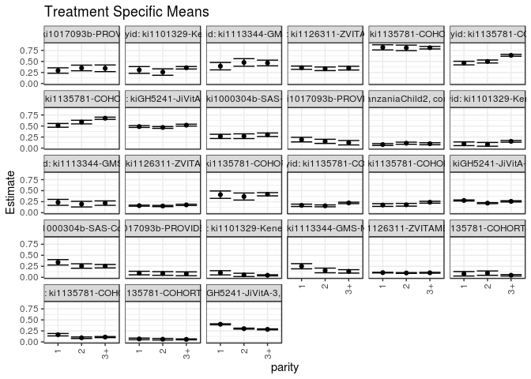

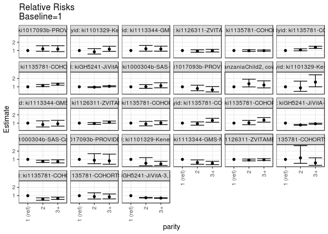

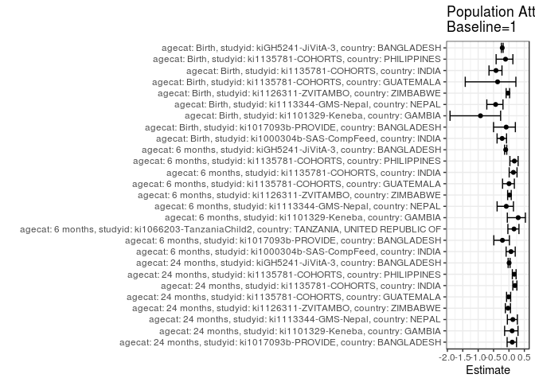

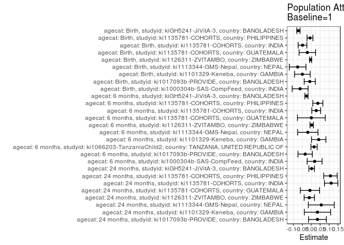

## Results Table

### Parameter: TSM

| agecat | studyid | country | intervention_level | baseline_level | estimate | ci_lower | ci_upper |
| --- | --- | --- | --- | --- | --- | --- | --- |
| Birth | ki1000304b-SAS-CompFeed | INDIA | 1 | NA | 0.3407202 | 0.2790148 | 0.4024256 |
| Birth | ki1000304b-SAS-CompFeed | INDIA | 2 | NA | 0.2560554 | 0.2057907 | 0.3063200 |
| Birth | ki1000304b-SAS-CompFeed | INDIA | 3+ | NA | 0.2524917 | 0.2130836 | 0.2918998 |
| Birth | ki1017093b-PROVIDE | BANGLADESH | 1 | NA | 0.0970874 | 0.0566184 | 0.1375563 |
| Birth | ki1017093b-PROVIDE | BANGLADESH | 2 | NA | 0.0874317 | 0.0464686 | 0.1283948 |
| Birth | ki1017093b-PROVIDE | BANGLADESH | 3+ | NA | 0.0800000 | 0.0365445 | 0.1234555 |
| Birth | ki1101329-Keneba | GAMBIA | 1 | NA | 0.1025641 | 0.0549386 | 0.1501896 |
| Birth | ki1101329-Keneba | GAMBIA | 2 | NA | 0.0547945 | 0.0178664 | 0.0917227 |
| Birth | ki1101329-Keneba | GAMBIA | 3+ | NA | 0.0461538 | 0.0337783 | 0.0585294 |
| Birth | ki1113344-GMS-Nepal | NEPAL | 1 | NA | 0.2511848 | 0.1926246 | 0.3097451 |
| Birth | ki1113344-GMS-Nepal | NEPAL | 2 | NA | 0.1555556 | 0.1025706 | 0.2085405 |
| Birth | ki1113344-GMS-Nepal | NEPAL | 3+ | NA | 0.1344262 | 0.0961169 | 0.1727355 |
| Birth | ki1126311-ZVITAMBO | ZIMBABWE | 1 | NA | 0.1068626 | 0.0990380 | 0.1146871 |
| Birth | ki1126311-ZVITAMBO | ZIMBABWE | 2 | NA | 0.0986969 | 0.0896158 | 0.1077781 |
| Birth | ki1126311-ZVITAMBO | ZIMBABWE | 3+ | NA | 0.1029137 | 0.0931767 | 0.1126506 |
| Birth | ki1135781-COHORTS | GUATEMALA | 1 | NA | 0.0803571 | 0.0299820 | 0.1307322 |
| Birth | ki1135781-COHORTS | GUATEMALA | 2 | NA | 0.0948905 | 0.0457879 | 0.1439931 |
| Birth | ki1135781-COHORTS | GUATEMALA | 3+ | NA | 0.0464345 | 0.0296294 | 0.0632396 |
| Birth | ki1135781-COHORTS | INDIA | 1 | NA | 0.1637931 | 0.1362951 | 0.1912911 |
| Birth | ki1135781-COHORTS | INDIA | 2 | NA | 0.0945034 | 0.0766969 | 0.1123099 |
| Birth | ki1135781-COHORTS | INDIA | 3+ | NA | 0.1100879 | 0.0975352 | 0.1226406 |
| Birth | ki1135781-COHORTS | PHILIPPINES | 1 | NA | 0.0681481 | 0.0491344 | 0.0871619 |
| Birth | ki1135781-COHORTS | PHILIPPINES | 2 | NA | 0.0611354 | 0.0432174 | 0.0790533 |
| Birth | ki1135781-COHORTS | PHILIPPINES | 3+ | NA | 0.0586493 | 0.0474384 | 0.0698602 |
| Birth | kiGH5241-JiVitA-3 | BANGLADESH | 1 | NA | 0.4006170 | 0.3887320 | 0.4125019 |
| Birth | kiGH5241-JiVitA-3 | BANGLADESH | 2 | NA | 0.3009849 | 0.2889559 | 0.3130139 |
| Birth | kiGH5241-JiVitA-3 | BANGLADESH | 3+ | NA | 0.2854821 | 0.2741503 | 0.2968140 |
| 6 months | ki1000304b-SAS-CompFeed | INDIA | 1 | NA | 0.2653061 | 0.2173742 | 0.3132380 |
| 6 months | ki1000304b-SAS-CompFeed | INDIA | 2 | NA | 0.2697368 | 0.2160109 | 0.3234628 |
| 6 months | ki1000304b-SAS-CompFeed | INDIA | 3+ | NA | 0.3031250 | 0.2636267 | 0.3426233 |

[output cut: 51 more lines]

### Parameter: E(Y)

| agecat | studyid | country | intervention_level | baseline_level | estimate | ci_lower | ci_upper |
| --- | --- | --- | --- | --- | --- | --- | --- |
| Birth | ki1000304b-SAS-CompFeed | INDIA | NA | NA | 0.2787540 | 0.2475949 | 0.3099131 |
| Birth | ki1017093b-PROVIDE | BANGLADESH | NA | NA | 0.0890538 | 0.0649864 | 0.1131212 |
| Birth | ki1101329-Keneba | GAMBIA | NA | NA | 0.0533049 | 0.0415629 | 0.0650470 |
| Birth | ki1113344-GMS-Nepal | NEPAL | NA | NA | 0.1752874 | 0.1470202 | 0.2035545 |
| Birth | ki1126311-ZVITAMBO | ZIMBABWE | NA | NA | 0.1033588 | 0.0982930 | 0.1084246 |
| Birth | ki1135781-COHORTS | GUATEMALA | NA | NA | 0.0586854 | 0.0428942 | 0.0744767 |
| Birth | ki1135781-COHORTS | INDIA | NA | NA | 0.1152353 | 0.1054865 | 0.1249842 |
| Birth | ki1135781-COHORTS | PHILIPPINES | NA | NA | 0.0613115 | 0.0527962 | 0.0698268 |
| Birth | kiGH5241-JiVitA-3 | BANGLADESH | NA | NA | 0.3289690 | 0.3216017 | 0.3363364 |
| 6 months | ki1000304b-SAS-CompFeed | INDIA | NA | NA | 0.2844311 | 0.2666491 | 0.3022132 |
| 6 months | ki1017093b-PROVIDE | BANGLADESH | NA | NA | 0.1589404 | 0.1297581 | 0.1881227 |
| 6 months | ki1066203-TanzaniaChild2 | TANZANIA, UNITED REPUBLIC OF | NA | NA | 0.0967419 | 0.0837671 | 0.1097166 |
| 6 months | ki1101329-Keneba | GAMBIA | NA | NA | 0.1398645 | 0.1229849 | 0.1567440 |
| 6 months | ki1113344-GMS-Nepal | NEPAL | NA | NA | 0.2163121 | 0.1823021 | 0.2503220 |
| 6 months | ki1126311-ZVITAMBO | ZIMBABWE | NA | NA | 0.1628980 | 0.1551237 | 0.1706723 |
| 6 months | ki1135781-COHORTS | GUATEMALA | NA | NA | 0.4099896 | 0.3788775 | 0.4411017 |
| 6 months | ki1135781-COHORTS | INDIA | NA | NA | 0.1957586 | 0.1838852 | 0.2076319 |
| 6 months | ki1135781-COHORTS | PHILIPPINES | NA | NA | 0.2112260 | 0.1958496 | 0.2266024 |
| 6 months | kiGH5241-JiVitA-3 | BANGLADESH | NA | NA | 0.2513830 | 0.2432594 | 0.2595066 |
| 24 months | ki1017093b-PROVIDE | BANGLADESH | NA | NA | 0.3287197 | 0.2903909 | 0.3670485 |
| 24 months | ki1101329-Keneba | GAMBIA | NA | NA | 0.3415698 | 0.3165034 | 0.3666361 |
| 24 months | ki1113344-GMS-Nepal | NEPAL | NA | NA | 0.4487705 | 0.4045970 | 0.4929440 |
| 24 months | ki1126311-ZVITAMBO | ZIMBABWE | NA | NA | 0.3471629 | 0.3241082 | 0.3702176 |
| 24 months | ki1135781-COHORTS | GUATEMALA | NA | NA | 0.8120301 | 0.7885439 | 0.8355162 |
| 24 months | ki1135781-COHORTS | INDIA | NA | NA | 0.5742604 | 0.5575886 | 0.5909321 |
| 24 months | ki1135781-COHORTS | PHILIPPINES | NA | NA | 0.6229039 | 0.6036892 | 0.6421186 |
| 24 months | kiGH5241-JiVitA-3 | BANGLADESH | NA | NA | 0.4910797 | 0.4779658 | 0.5041936 |

### Parameter: RR

| agecat | studyid | country | intervention_level | baseline_level | estimate | ci_lower | ci_upper |
| --- | --- | --- | --- | --- | --- | --- | --- |
| Birth | ki1000304b-SAS-CompFeed | INDIA | 1 | 1 | 1.0000000 | 1.0000000 | 1.0000000 |
| Birth | ki1000304b-SAS-CompFeed | INDIA | 2 | 1 | 0.7515121 | 0.6253629 | 0.9031082 |
| Birth | ki1000304b-SAS-CompFeed | INDIA | 3+ | 1 | 0.7410529 | 0.5767607 | 0.9521442 |
| Birth | ki1017093b-PROVIDE | BANGLADESH | 1 | 1 | 1.0000000 | 1.0000000 | 1.0000000 |
| Birth | ki1017093b-PROVIDE | BANGLADESH | 2 | 1 | 0.9005464 | 0.4810166 | 1.6859789 |
| Birth | ki1017093b-PROVIDE | BANGLADESH | 3+ | 1 | 0.8240000 | 0.4154972 | 1.6341289 |
| Birth | ki1101329-Keneba | GAMBIA | 1 | 1 | 1.0000000 | 1.0000000 | 1.0000000 |
| Birth | ki1101329-Keneba | GAMBIA | 2 | 1 | 0.5342466 | 0.2356709 | 1.2110933 |
| Birth | ki1101329-Keneba | GAMBIA | 3+ | 1 | 0.4500000 | 0.2632335 | 0.7692791 |
| Birth | ki1113344-GMS-Nepal | NEPAL | 1 | 1 | 1.0000000 | 1.0000000 | 1.0000000 |
| Birth | ki1113344-GMS-Nepal | NEPAL | 2 | 1 | 0.6192872 | 0.4098564 | 0.9357342 |
| Birth | ki1113344-GMS-Nepal | NEPAL | 3+ | 1 | 0.5351686 | 0.3703268 | 0.7733857 |
| Birth | ki1126311-ZVITAMBO | ZIMBABWE | 1 | 1 | 1.0000000 | 1.0000000 | 1.0000000 |
| Birth | ki1126311-ZVITAMBO | ZIMBABWE | 2 | 1 | 0.9235872 | 0.8211257 | 1.0388341 |
| Birth | ki1126311-ZVITAMBO | ZIMBABWE | 3+ | 1 | 0.9630467 | 0.8544565 | 1.0854374 |
| Birth | ki1135781-COHORTS | GUATEMALA | 1 | 1 | 1.0000000 | 1.0000000 | 1.0000000 |
| Birth | ki1135781-COHORTS | GUATEMALA | 2 | 1 | 1.1808597 | 0.5238079 | 2.6621012 |
| Birth | ki1135781-COHORTS | GUATEMALA | 3+ | 1 | 0.5778515 | 0.2801877 | 1.1917454 |
| Birth | ki1135781-COHORTS | INDIA | 1 | 1 | 1.0000000 | 1.0000000 | 1.0000000 |
| Birth | ki1135781-COHORTS | INDIA | 2 | 1 | 0.5769680 | 0.4482824 | 0.7425945 |
| Birth | ki1135781-COHORTS | INDIA | 3+ | 1 | 0.6721156 | 0.5486645 | 0.8233437 |
| Birth | ki1135781-COHORTS | PHILIPPINES | 1 | 1 | 1.0000000 | 1.0000000 | 1.0000000 |
| Birth | ki1135781-COHORTS | PHILIPPINES | 2 | 1 | 0.8970951 | 0.5985491 | 1.3445507 |
| Birth | ki1135781-COHORTS | PHILIPPINES | 3+ | 1 | 0.8606146 | 0.6136598 | 1.2069511 |
| Birth | kiGH5241-JiVitA-3 | BANGLADESH | 1 | 1 | 1.0000000 | 1.0000000 | 1.0000000 |
| Birth | kiGH5241-JiVitA-3 | BANGLADESH | 2 | 1 | 0.7513034 | 0.7166931 | 0.7875852 |
| Birth | kiGH5241-JiVitA-3 | BANGLADESH | 3+ | 1 | 0.7126062 | 0.6787683 | 0.7481310 |
| 6 months | ki1000304b-SAS-CompFeed | INDIA | 1 | 1 | 1.0000000 | 1.0000000 | 1.0000000 |
| 6 months | ki1000304b-SAS-CompFeed | INDIA | 2 | 1 | 1.0167004 | 0.8134162 | 1.2707882 |
| 6 months | ki1000304b-SAS-CompFeed | INDIA | 3+ | 1 | 1.1425481 | 0.8761040 | 1.4900241 |

[output cut: 51 more lines]

### Parameter: PAR

| agecat | studyid | country | intervention_level | baseline_level | estimate | ci_lower | ci_upper |
| --- | --- | --- | --- | --- | --- | --- | --- |
| Birth | ki1000304b-SAS-CompFeed | INDIA | 1 | NA | -0.0619662 | -0.1064085 | -0.0175240 |
| Birth | ki1017093b-PROVIDE | BANGLADESH | 1 | NA | -0.0080336 | -0.0391001 | 0.0230329 |
| Birth | ki1101329-Keneba | GAMBIA | 1 | NA | -0.0492592 | -0.0928837 | -0.0056347 |
| Birth | ki1113344-GMS-Nepal | NEPAL | 1 | NA | -0.0758975 | -0.1222556 | -0.0295394 |
| Birth | ki1126311-ZVITAMBO | ZIMBABWE | 1 | NA | -0.0035038 | -0.0093372 | 0.0023296 |
| Birth | ki1135781-COHORTS | GUATEMALA | 1 | NA | -0.0216717 | -0.0677134 | 0.0243700 |
| Birth | ki1135781-COHORTS | INDIA | 1 | NA | -0.0485578 | -0.0729674 | -0.0241481 |
| Birth | ki1135781-COHORTS | PHILIPPINES | 1 | NA | -0.0068367 | -0.0233901 | 0.0097167 |
| Birth | kiGH5241-JiVitA-3 | BANGLADESH | 1 | NA | -0.0716479 | -0.0810006 | -0.0622952 |
| 6 months | ki1000304b-SAS-CompFeed | INDIA | 1 | NA | 0.0191250 | -0.0225940 | 0.0608440 |
| 6 months | ki1017093b-PROVIDE | BANGLADESH | 1 | NA | -0.0337202 | -0.0739101 | 0.0064698 |
| 6 months | ki1066203-TanzaniaChild2 | TANZANIA, UNITED REPUBLIC OF | 1 | NA | 0.0158595 | -0.0015211 | 0.0332401 |
| 6 months | ki1101329-Keneba | GAMBIA | 1 | NA | 0.0419263 | 0.0017156 | 0.0821370 |
| 6 months | ki1113344-GMS-Nepal | NEPAL | 1 | NA | -0.0189821 | -0.0757880 | 0.0378239 |
| 6 months | ki1126311-ZVITAMBO | ZIMBABWE | 1 | NA | 0.0027711 | -0.0067313 | 0.0122734 |
| 6 months | ki1135781-COHORTS | GUATEMALA | 1 | NA | 0.0008987 | -0.0770478 | 0.0788451 |
| 6 months | ki1135781-COHORTS | INDIA | 1 | NA | 0.0281910 | 0.0033828 | 0.0529991 |
| 6 months | ki1135781-COHORTS | PHILIPPINES | 1 | NA | 0.0370100 | 0.0088802 | 0.0651397 |
| 6 months | kiGH5241-JiVitA-3 | BANGLADESH | 1 | NA | -0.0266032 | -0.0355913 | -0.0176152 |
| 24 months | ki1017093b-PROVIDE | BANGLADESH | 1 | NA | 0.0348809 | -0.0150235 | 0.0847852 |
| 24 months | ki1101329-Keneba | GAMBIA | 1 | NA | 0.0350004 | -0.0385228 | 0.1085236 |
| 24 months | ki1113344-GMS-Nepal | NEPAL | 1 | NA | 0.0564628 | -0.0159902 | 0.1289158 |
| 24 months | ki1126311-ZVITAMBO | ZIMBABWE | 1 | NA | -0.0106496 | -0.0395253 | 0.0182261 |
| 24 months | ki1135781-COHORTS | GUATEMALA | 1 | NA | -0.0072470 | -0.0612011 | 0.0467071 |
| 24 months | ki1135781-COHORTS | INDIA | 1 | NA | 0.1114944 | 0.0739911 | 0.1489977 |
| 24 months | ki1135781-COHORTS | PHILIPPINES | 1 | NA | 0.1076367 | 0.0700091 | 0.1452644 |
| 24 months | kiGH5241-JiVitA-3 | BANGLADESH | 1 | NA | 0.0025830 | -0.0129061 | 0.0180721 |

### Parameter: PAF

| agecat | studyid | country | intervention_level | baseline_level | estimate | ci_lower | ci_upper |
| --- | --- | --- | --- | --- | --- | --- | --- |
| Birth | ki1000304b-SAS-CompFeed | INDIA | 1 | NA | -0.2222972 | -0.3858851 | -0.0780189 |
| Birth | ki1017093b-PROVIDE | BANGLADESH | 1 | NA | -0.0902104 | -0.5004124 | 0.2078454 |
| Birth | ki1101329-Keneba | GAMBIA | 1 | NA | -0.9241025 | -1.9135260 | -0.2706839 |
| Birth | ki1113344-GMS-Nepal | NEPAL | 1 | NA | -0.4329889 | -0.7190791 | -0.1945100 |
| Birth | ki1126311-ZVITAMBO | ZIMBABWE | 1 | NA | -0.0338992 | -0.0918869 | 0.0210089 |
| Birth | ki1135781-COHORTS | GUATEMALA | 1 | NA | -0.3692857 | -1.4191803 | 0.2249675 |
| Birth | ki1135781-COHORTS | INDIA | 1 | NA | -0.4213793 | -0.6476006 | -0.2262190 |
| Birth | ki1135781-COHORTS | PHILIPPINES | 1 | NA | -0.1115072 | -0.4166265 | 0.1278941 |
| Birth | kiGH5241-JiVitA-3 | BANGLADESH | 1 | NA | -0.2177953 | -0.2470031 | -0.1892715 |
| 6 months | ki1000304b-SAS-CompFeed | INDIA | 1 | NA | 0.0672395 | -0.0924640 | 0.2035965 |
| 6 months | ki1017093b-PROVIDE | BANGLADESH | 1 | NA | -0.2121560 | -0.4913178 | 0.0147492 |
| 6 months | ki1066203-TanzaniaChild2 | TANZANIA, UNITED REPUBLIC OF | 1 | NA | 0.1639363 | -0.0351138 | 0.3247095 |
| 6 months | ki1101329-Keneba | GAMBIA | 1 | NA | 0.2997638 | -0.0530775 | 0.5343831 |
| 6 months | ki1113344-GMS-Nepal | NEPAL | 1 | NA | -0.0877531 | -0.3845934 | 0.1454481 |
| 6 months | ki1126311-ZVITAMBO | ZIMBABWE | 1 | NA | 0.0170111 | -0.0430841 | 0.0736440 |
| 6 months | ki1135781-COHORTS | GUATEMALA | 1 | NA | 0.0021920 | -0.2072456 | 0.1752955 |
| 6 months | ki1135781-COHORTS | INDIA | 1 | NA | 0.1440090 | 0.0076228 | 0.2616511 |
| 6 months | ki1135781-COHORTS | PHILIPPINES | 1 | NA | 0.1752150 | 0.0310883 | 0.2979027 |
| 6 months | kiGH5241-JiVitA-3 | BANGLADESH | 1 | NA | -0.1058274 | -0.1420364 | -0.0707665 |
| 24 months | ki1017093b-PROVIDE | BANGLADESH | 1 | NA | 0.1061112 | -0.0592824 | 0.2456807 |
| 24 months | ki1101329-Keneba | GAMBIA | 1 | NA | 0.1024693 | -0.1407748 | 0.2938472 |
| 24 months | ki1113344-GMS-Nepal | NEPAL | 1 | NA | 0.1258166 | -0.0517432 | 0.2734001 |
| 24 months | ki1126311-ZVITAMBO | ZIMBABWE | 1 | NA | -0.0306761 | -0.1173031 | 0.0492346 |
| 24 months | ki1135781-COHORTS | GUATEMALA | 1 | NA | -0.0089246 | -0.0776089 | 0.0553819 |
| 24 months | ki1135781-COHORTS | INDIA | 1 | NA | 0.1941530 | 0.1258176 | 0.2571467 |
| 24 months | ki1135781-COHORTS | PHILIPPINES | 1 | NA | 0.1727983 | 0.1096941 | 0.2314296 |
| 24 months | kiGH5241-JiVitA-3 | BANGLADESH | 1 | NA | 0.0052599 | -0.0267937 | 0.0363128 |